# Predicting Movie Success

In this notebook, we build and evaluate models to predict movie success using data from TMDb. We begin by training a random forest classifier with **frequency encoding** for categorical variables. After constructing the model, we assess its performance, visualize how it makes decisions (including sample trees and feature importance), and use it to make predictions — including on movies released this year.

Next, we enhance the model by **adding categorical scores** to the feature set — a more nuanced approach that captures the historical performance of individual directors, cast members, writers, and production companies. We repeat the full evaluation pipeline for this improved model and find it delivers better results, particularly in terms of **increased precision**.

Finally, using the superior model, we explore **partial dependence plots** to gain insight into how specific features influence predictions. We conclude with **business takeaways** that highlight actionable patterns learned by the model.

```python
import pandas as pd
import numpy as np
import datetime
import matplotlib.pyplot as plt
import seaborn as sns
import data_processing.load_sqlite as load_sql
from sklearn.model_selection import train_test_split
from sklearn.ensemble import RandomForestClassifier
from sklearn.metrics import precision_score, recall_score
from sklearn.tree import plot_tree
from sklearn.inspection import PartialDependenceDisplay
```

## Defining Success

In this project we are using movie data obtained from The Movie Database (TMDB). This site provides a *vote average* (from 0 to 10) for each movie that we use to determine whether or not a movie was successful. More precisely, **we define a movie to be successful if it has a vote average above 7.0**.

## Fetching Movie Data

```python
df = load_sql.fetch_movie_rating_features()
df.head()
```

|  | movie_id | vote_average | title | release_date | runtime | vote_count | top_cast_id | top_2_cast_ids | top_5_cast_ids | num_cast_members | director_ids | writer_ids | company_ids | genre_ids |
| --- | --- | --- | --- | --- | --- | --- | --- | --- | --- | --- | --- | --- | --- | --- |
| 0 | 2 | 7.113 | Ariel | 1988-10-21 | 73 | 341 | None | None | None | 0 | None | None | 2303 | 18,35,80,10749 |
| 1 | 3 | 7.300 | Shadows in Paradise | 1986-10-17 | 74 | 404 | None | None | None | 0 | None | None | 2303 | 18,35,10749 |
| 2 | 5 | 5.858 | Four Rooms | 1995-12-09 | 98 | 2674 | 3129 | 3129,3130 | 3129,3130,3131,3124,2555 | 28 | 138,2294,3110,3111 | 138,2294,3110,3111 | 14,59 | 35,80 |
| 3 | 6 | 6.500 | Judgment Night | 1993-10-15 | 109 | 345 | 2880 | 2880,9777 | 2880,9777,5724,10822,12799 | 31 | 2042 | 52035,52035,1088307 | 33,182,1644 | 28,53,80 |
| 4 | 11 | 8.200 | Star Wars | 1977-05-25 | 121 | 20915 | 2 | 2,3 | 2,3,4,5,12248 | 104 | 1 | 1 | 1,25 | 12,28,878 |

## Pre-split Processing

```python
def pre_split_processing(df):
    """
    Perform pre-split processing on the movie data.

    - Convert 'release_date' to Unix timestamp (seconds).
    - Create a 'successful' column where success is defined by vote_average > 7.0.
    """
    df = df.copy()
    df['release_date'] = pd.to_datetime(df['release_date'])
    df['release_date'] = df['release_date'].astype(int) / 10**9
    df['successful'] = (df['vote_average'] > 7.0).astype(int)

    return df
```

```python
df = pre_split_processing(df)
df.head()
```

|  | movie_id | vote_average | title | release_date | runtime | vote_count | top_cast_id | top_2_cast_ids | top_5_cast_ids | num_cast_members | director_ids | writer_ids | company_ids | genre_ids | successful |
| --- | --- | --- | --- | --- | --- | --- | --- | --- | --- | --- | --- | --- | --- | --- | --- |
| 0 | 2 | 7.113 | Ariel | 593395200.0 | 73 | 341 | None | None | None | 0 | None | None | 2303 | 18,35,80,10749 | 1 |
| 1 | 3 | 7.300 | Shadows in Paradise | 529891200.0 | 74 | 404 | None | None | None | 0 | None | None | 2303 | 18,35,10749 | 1 |
| 2 | 5 | 5.858 | Four Rooms | 818467200.0 | 98 | 2674 | 3129 | 3129,3130 | 3129,3130,3131,3124,2555 | 28 | 138,2294,3110,3111 | 138,2294,3110,3111 | 14,59 | 35,80 | 0 |
| 3 | 6 | 6.500 | Judgment Night | 750643200.0 | 109 | 345 | 2880 | 2880,9777 | 2880,9777,5724,10822,12799 | 31 | 2042 | 52035,52035,1088307 | 33,182,1644 | 28,53,80 | 0 |
| 4 | 11 | 8.200 | Star Wars | 233366400.0 | 121 | 20915 | 2 | 2,3 | 2,3,4,5,12248 | 104 | 1 | 1 | 1,25 | 12,28,878 | 1 |

```python
print(f"The proportion of movies that are successful: {df['successful'].mean(): .4f}")
```

```
The proportion of movies that are successful:  0.2074
```

## Preparing the Data with Frequency Encoding

First, we split the dataset into training and testing sets to avoid data leakage during the frequency encoding process.

```python
train_df, test_df = train_test_split(df, test_size=0.2, random_state=42)
print(f"Train set size: {len(train_df)}")
print(f"Test set size: {len(test_df)}")
```

```
Train set size: 35617
Test set size: 8905
```

We wrap the logic of frequency encoding into a function since we will use it later:

```python
def add_frequency_encoding(train_df, test_df, categorical_cols, default_freq=1):
    """
    Adds frequency-encoded versions of the categorical columns to both train and test dataframes.

    Parameters:
        train_df (pd.DataFrame): Training dataframe.
        test_df (pd.DataFrame): Test dataframe.
        categorical_cols (list): List of categorical column names.
        default_freq (int): Frequency to assign to unseen values in test data.

    Returns:
        train_df, test_df (pd.DataFrames): Updated dataframes with frequency-encoded columns.
    """
    for col in categorical_cols:
        freq_map = train_df[col].value_counts().to_dict()

        train_df[col + '_freq'] = train_df[col].map(freq_map).fillna(default_freq)
        test_df[col + '_freq'] = test_df[col].map(freq_map).fillna(default_freq)

    return train_df, test_df
```

Now we specify the categorical features to use, and apply frequency encoding:

```python
categorical_cols = ['company_ids', 'top_cast_id', 'top_2_cast_ids', 'top_5_cast_ids', 'director_ids', 'writer_ids', 'genre_ids']
train_df, test_df = add_frequency_encoding(train_df, test_df, categorical_cols)
```

The last thing to do before training the random forest model is to remove the non-numerical columns and split the data into the appropriate features and target. Again, we wrap this in a function for later use.

```python
def prepare_features(df, target_col="successful", drop_cols=["vote_average", "vote_count", "successful", "movie_id"]):
    """
    Selects numeric features for modeling, excluding specified columns.

    Parameters:
        df (pd.DataFrame): The input dataframe.
        target_col (str): Name of the target column.
        drop_cols (list): Columns to drop from features.

    Returns:
        X (pd.DataFrame): Feature matrix.
        y (pd.Series): Target vector.
    """
    features_to_keep = df.select_dtypes(include=["float64", "int64"]).columns
    X = df[features_to_keep].drop(columns=drop_cols)
    y = df[target_col]
    return X, y
```

Applying this function to the training and testing datasets is the final preprocessing step:

```python
X_train, y_train = prepare_features(train_df)
X_test, y_test = prepare_features(test_df)
```

## Making the Model: A Random Forest Classifier

Now that the data is properly preprocessed, we are ready to create the random forest model.

```python
rf = RandomForestClassifier(
    n_estimators=200,
    max_depth=10,
    min_samples_split=10,
    min_samples_leaf=5,
    max_features="sqrt",
    bootstrap=True,
    oob_score=True,
    random_state=42
)

rf.fit(X_train, y_train)

print("Training score:", rf.score(X_train, y_train))
print("Testing score:", rf.score(X_test, y_test))
```

```
Training score: 0.8136002470730269
Testing score: 0.7977540707467715
```

## Evaluating the Model

Although the random forest model achieves an overall accuracy of around 80%, this number is somewhat misleading due to the imbalance in the dataset: only about 20% of the movies are actually successful (as shown above). A model could reach 80% accuracy simply by predicting that no movies will be successful, which obviously wouldn't be helpful.

Let's take a look to see if the model is predicting any successes:

```python
pred = rf.predict(X_test)
print(f"Total number of movies in test set: {len(X_test)}")
print(f"Total number of successful movies in test set: {y_test.sum()}")
print(f"Number of movies in test set predicted successful: {pred.sum()}")
print(f"Proportion of movies in test set predicted successful: {pred.sum()/len(X_test): .4f}")
```

```
Total number of movies in test set: 8905
Total number of successful movies in test set: 1843
Number of movies in test set predicted successful: 208
Proportion of movies in test set predicted successful:  0.0234
```

It does look like the model is not predicting very many successful movies. However, since our model does identify some movies as likely to be successful, it may still be worthwhile. Indeed, if the movies it predicts to be successful actually are, then the model could still be quite useful—for example, in flagging a handful of high-potential movies for further investment or marketing. This is where precision becomes especially important: it tells us, out of all the movies the model predicts to be successful, how many of them truly are. Let's take a closer look at the model’s precision and recall to evaluate this aspect.

```python
print(f"Precision: {precision_score(y_test, pred): .4f} (probability that a predicted success is actually successful)")
print(f"Recall:    {recall_score(y_test, pred): .4f} (probability that an actual success is predicted successful)")
```

```
Precision:  0.6010 (probability that a predicted success is actually successful)
Recall:     0.0678 (probability that an actual success is predicted successful)
```

The recall is quite low, which is just restating that the model is not predicting many successes (relative to the true number of successes). On the other hand, the precision shows that when the model predicts a movie to be a success there is about a 60% chance of that movie being successful. While this is not a super high hit rate, it indicates that the model may be useful.

## Understanding the Model

To provide insight into how the model works, we first visualize a single decision tree from the random forest ensemble. Since a full tree is too large to follow in detail, we only show the first few levels of decisions. While this certainly does not give us a full understanding of the model, it does this gives a sense of the types of decisions the model makes.

Later, to get a more global understanding of how the forest is making decisions, we will take a look at the feature importance over all the trees in the forest. First, let's look at some of the trees.

### Visualizing Trees

The following function allows use to see various trees from our random forest model:

```python
def plot_random_forest_tree(rf_model, feature_names, tree_index=0, max_depth=None, class_names=["Not Successful", "Successful"], figsize=(20, 10)):
    """
    Plots a decision tree from a trained Random Forest model.

    Parameters:
    - rf_model: The trained RandomForestClassifier object.
    - feature_names: A list of feature names used in training.
    - tree_index: Index of the tree within the random forest to visualize.
    - max_depth: Limits the depth of the tree displayed (None = full tree).
    - class_names: Labels for the target classes.
    - figsize: Size of the figure.
    """
    if tree_index >= len(rf_model.estimators_):
        raise ValueError(f"Tree index {tree_index} is out of bounds for the forest with {len(rf_model.estimators_)} trees.")

    estimator = rf_model.estimators_[tree_index]

    plt.figure(figsize=figsize)
    plot_tree(estimator,
              max_depth=max_depth,
              filled=True,
              feature_names=feature_names,
              class_names=class_names,
              rounded=True,
              fontsize=10)
    plt.title(f"Decision Tree {tree_index} from Random Forest (Depth: {max_depth})")
    plt.show()
```

Let's use the function to see the top of a couple trees:

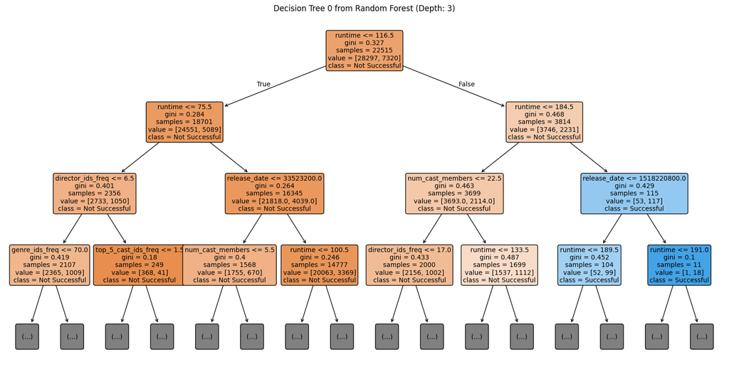

```python
plot_random_forest_tree(rf, feature_names=X_train.columns, tree_index=0, max_depth=3)
```

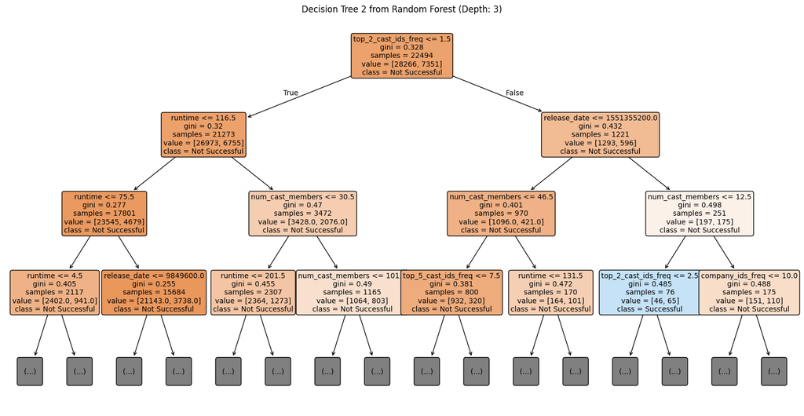

```python
plot_random_forest_tree(rf, feature_names=X_train.columns, tree_index=2, max_depth=3)
```

### Feature Importance

Next, we examine the feature importance scores, which quantify how much each variable contributed to the final predictions across all trees in the forest. The following function will give us these importance scores in a convinient format:

```python
def get_feature_importance_df(rf_model, feature_names, top_n=None):
    """
    Returns a DataFrame of feature importances sorted by importance.

    Parameters:
    - rf_model: Trained RandomForestClassifier
    - feature_names: List or Index of feature names
    - top_n: Optional integer to limit the number of features returned

    Returns:
    - pandas DataFrame with 'Feature' and 'Importance' columns
    """
    importances = rf_model.feature_importances_
    df = pd.DataFrame({
        'Feature': feature_names,
        'Importance': importances
    }).sort_values(by='Importance', ascending=False)

    if top_n is not None:
        df = df.head(top_n)

    return df
```

Let's see what the most important features are for the random forest model:

```python
get_feature_importance_df(rf, X_train.columns).head()
```

|  | Feature | Importance |
| --- | --- | --- |
| 1 | runtime | 0.358005 |
| 9 | genre_ids_freq | 0.199020 |
| 0 | release_date | 0.164158 |
| 2 | num_cast_members | 0.081138 |
| 3 | company_ids_freq | 0.053080 |

We can visualize these importance scores nicely with a bar chart:

```python
def plot_feature_importance(rf_model, feature_names, top_n=None):
    """
    Plots the feature importances as a bar chart.

    Parameters:
    - rf_model: Trained RandomForestClassifier
    - feature_names: List or Index of feature names
    - top_n: Optional integer to limit to top N features

    Returns:
    - matplotlib Figure object (not shown automatically)
    """
    df = get_feature_importance_df(rf_model, feature_names, top_n=top_n)

    fig, ax = plt.subplots(figsize=(10, 6))
    sns.barplot(
        x="Importance",
        y="Feature",
        data=df,
        hue="Feature",
        palette="viridis",
        legend=False,
        ax=ax
    )
    ax.set_xlabel("Feature Importance")
    ax.set_ylabel("Feature")
    ax.set_title("Feature Importance in Random Forest Model")
    fig.tight_layout()
    plt.close(fig)

    return fig
```

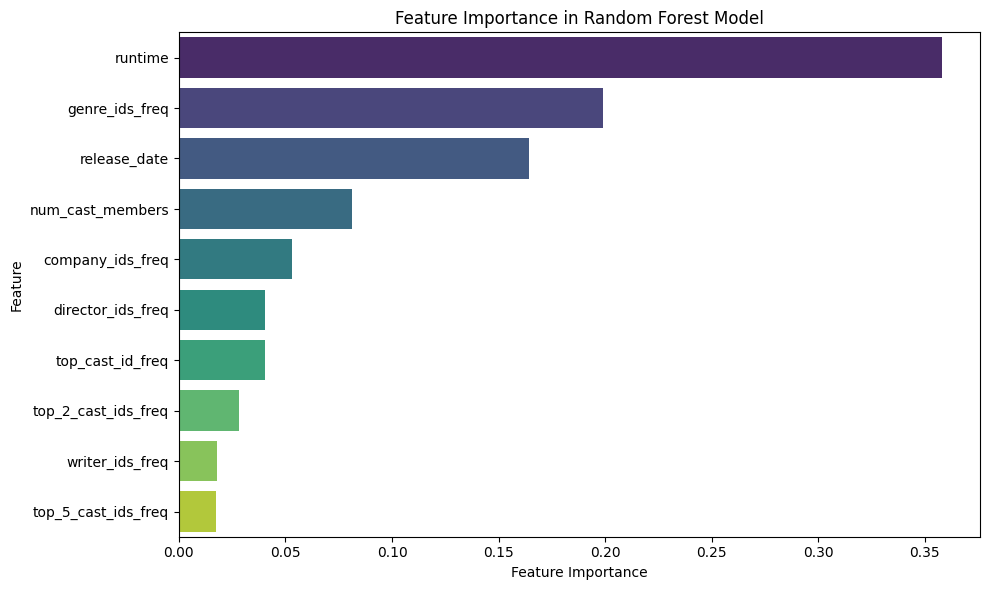

```python
plot_feature_importance(rf, X_train.columns)
```

## Using the Model

Let's try the model out by predicting whether or not movies released during the current year will be successful.

The data that we used to train and test the model restricted to movies with at least 30 votes so that we could be confident in each movies vote average. Of course, we would like to predict the success of movies before any votes have been cast. Thus, we first fetch all the movie data regardless of how many votes the movie has.

```python
df_all = load_sql.fetch_movie_rating_features(min_votes=0)
```

Next, we filter to the movies with release dates matching the current year:

```python
current_year = str(datetime.datetime.now().year)
new_movies = df_all[df_all['release_date'].str.startswith(current_year)]
new_movies.head()
```

|  | movie_id | vote_average | title | release_date | runtime | vote_count | top_cast_id | top_2_cast_ids | top_5_cast_ids | num_cast_members | director_ids | writer_ids | company_ids | genre_ids |
| --- | --- | --- | --- | --- | --- | --- | --- | --- | --- | --- | --- | --- | --- | --- |
| 56548 | 83533 | 0.0 | Avatar: Fire and Ash | 2025-12-17 | 0 | 0 | 65731 | 65731,8691 | 65731,8691,10205,32747,204 | 24 | 2710 | 507,2710,2710,2710,6039,67802,67802,67803,67803 | 574,127928 | 12,14,878 |
| 140012 | 257094 | 0.0 | Holland | 2025-03-09 | 108 | 0 | 2227 | 2227,258 | 2227,258,15576,1976054,3232669 | 10 | 1675644 | 1296509 | 20859,32537,81755,84988,210099 | 18,53,9648 |
| 155948 | 277171 | 0.0 | Thingdom: El reino de las cosas | 2025-12-31 | 86 | 0 | 150885 | 150885,1331278 | 150885,1331278 | 2 | 232264 | 232264 | None | None |
| 156808 | 278201 | 0.0 | Anpodu Kanmani | 2025-01-24 | 0 | 0 | 1440952 | 1440952,3276420 | 1440952,3276420,2037448,1855736,1696318 | 10 | 1734161 | 1857798,4982162,4982162 | 240870 | 18,10751 |
| 158997 | 280951 | 3.0 | Madha Gaja Raja | 2025-01-12 | 142 | 1 | 559892 | 559892,141076 | 559892,141076,1118770,123068,95750 | 19 | 584275 | 19292,66563,584275,1301701,1543835,2225883 | 27024 | 28,35,10749 |

Before using the model to make predictions, we need to process the data of new movies:

```python
new_movies = pre_split_processing(new_movies)
_, new_movies_encoded = add_frequency_encoding(train_df, new_movies, categorical_cols)
X_new_movies, _ = prepare_features(new_movies_encoded)
```

Now we can use the random forest model to make predictions

```python
predictions = rf.predict(X_new_movies)
print(f"Number of movies predicted successful: {(predictions == 1).sum()}")
print(f"Number of movies predicted unsuccessful: {(predictions == 0).sum()}")
print(f"Proportion of movies predicted successful: {(predictions == 1).sum()/len(X_new_movies): .4f}")
```

```
Number of movies predicted successful: 153
Number of movies predicted unsuccessful: 12375
Proportion of movies predicted successful:  0.0122
```

### Which movies will be successful this year?

The following cell shows us movies from the current year that the model predicts will be successful. Instead of just labelling each movie as successful/unsuccessful, we calculate the predicted probability of success for each movie. The results are stored in a new DataFrame, and the top 10 movies with the highest predicted probability of success are displayed, giving us a sense of which upcoming releases the model is most confident about.

```python
def get_most_likely_successful(rf, movies, features):
    """
    Uses a trained RandomForest model to predict movie success and returns a ranked list of the most likely successes.

    Parameters:
    -----------
    rf : sklearn.ensemble.RandomForestClassifier
        A trained Random Forest classifier for predicting movie success.

    movies : pandas.DataFrame
        A DataFrame containing metadata for each movie (e.g., title, genre). This should align with the `features` input by row.

    features : pandas.DataFrame or numpy.ndarray
        The feature matrix used to generate predictions, typically matching the training or test data format.

    Returns:
    --------
    pandas.DataFrame
        A DataFrame showing the top movies sorted by predicted probability of success, including:
        - 'title': the movie title
        - 'Success Probability': predicted probability of being successful (class 1)
        - 'Predicted Label': categorical label ('Successful' or 'Not Successful')
    """
    probas = rf.predict_proba(features)[:, 1]  # Probability of being 'Successful'
    predictions = rf.predict(features)
    results_df = movies.copy()
    results_df["Predicted Success"] = predictions
    results_df["Success Probability"] = probas
    results_df["Predicted Label"] = results_df["Predicted Success"].map({0: "Not Successful", 1: "Successful"})

    top_preds = results_df.sort_values(by="Success Probability", ascending=False)
    return top_preds[["title", "Success Probability", "Predicted Label"]]

get_most_likely_successful(rf, new_movies, X_new_movies).head(10)
```

|  | title | Success Probability | Predicted Label |
| --- | --- | --- | --- |
| 891160 | The AGFA Mystery Mixtape Vault | 0.717861 | Successful |
| 870249 | Palliative Care Unit | 0.717268 | Successful |
| 519395 | The Prince of Nanawa | 0.688814 | Successful |
| 870063 | Talking with Dream | 0.682478 | Successful |
| 888186 | A Body in the Snow: The Trial of Karen Read | 0.677935 | Successful |
| 820529 | Phantosmia | 0.666133 | Successful |
| 885832 | Šarović in Ćaciland | 0.654259 | Successful |
| 881927 | Cinextdoor presentéiert: Marginal | 0.652096 | Successful |
| 887788 | Requiem for Selina | 0.651807 | Successful |
| 886197 | THE CHIENNETE TV SHOW | 0.650860 | Successful |

## Going Beyond Frequency Encoding: Predicting Movie Success with Categorical Scores

In this section, we aim to improve on the random forest model developed earlier. Our previous approach relied on frequency encoding for categorical variables, which, while simple and effective in some cases, may fail to capture the full strength of the signal these features can carry.

Take the example of directors: frequency encoding simply counts how many movies a director has made. However, this doesn’t necessarily reflect the quality of those movies. Some of the greatest directors may choose to make only a few films, while others with large filmographies might have produced mostly mediocre ones. To capture this nuance, we introduce a new encoding strategy that scores each director based on the vote averages of their previous movies, giving more weight to recent films.

More precisely, we define a director score for a given movie as follows:

$$\text{Director Score} = \frac{\sum\limits_{m} \mathrm{vote\_ave}_m \cdot e^{-\lambda \cdot \text{days}_m} }{\sum\limits_{m} e^{-\lambda \cdot \text{days}_m}}$$

where the sums are taken over all prior movies $m$ by the same director and where:

- $\mathrm{vote\_ave}_m$ is the vote average for the previous movie $m$.
- $\text{days}_m$ is the number of days between the release of previous movie $m$ and the release of the current movie being scored.
- $\lambda$ is a decay parameter that controls how much recent movies are weighted more heavily than older ones.

This weighted average allows us to quantify the recent performance of a director, reflecting both quality and recency.

In a separate Notebook (see *helper_feature_engineering_scores.ipynb*) various values for $\lambda$ were tested with the goal of optimizing the correlation between the resulting director score and the movie's vote average. We found an optimal value for $\lambda$ to be about $\lambda=0.0004$.

We apply similar methods to other categorical features like the movie's cast and writers, replacing simple frequency counts with quality-weighted scores that better represent their past performance. We also compute a production company score as the average vote average of all prior films released by each company. This enriched encoding should give our model more predictive power and help it better identify potentially successful films. Here are the formulae we use for the Writers and Cast scores:

$$\text{Writers Score} = \frac{\sum\limits_{m} \mathrm{vote\_ave}_m \cdot e^{-\lambda \cdot \text{days}_m} }{\sum\limits_{m} e^{-\lambda \cdot \text{days}_m}}$$ $$\text{Cast Score} = \frac{\sum\limits_{m} \mathrm{vote\_ave}_m \cdot e^{-\lambda_t \cdot \text{days}_m-\lambda_o \cdot \mathrm{cast\_order}_m} }{\sum\limits_{m} e^{-\lambda_t \cdot \text{days}_m-\lambda_o \cdot \mathrm{cast\_order}_m} }$$

In the following cell, we hardcode the optimal $\lambda$-parameters for each of the categorical features, as determined in the notebook *helper_feature_engineering_scores.ipynb*. If this leads to a stronger model, we could revisit the problem of selecting these parameters more systematically. For example, rather than hardcoding, we could use a technique like gradient descent to learn suitable values directly from the data.

```python
lambda_director   = 0.0004
lambda_writers    = 0.0004
lambda_cast_time  = 0.00058
lambda_cast_order = 0.12

df_with_scores = load_sql.fetch_predict_success_data(lambda_director, lambda_writers, lambda_cast_time, lambda_cast_order)
df_with_scores.head()
```

|  | movie_id | vote_average | title | release_date | runtime | vote_count | top_cast_id | top_2_cast_ids | top_5_cast_ids | num_cast_members | ... | genre_Mystery | genre_Music | genre_Romance | genre_Family | genre_War | genre_TV Movie | director_score | writer_score | cast_score | production_company_score |
| --- | --- | --- | --- | --- | --- | --- | --- | --- | --- | --- | --- | --- | --- | --- | --- | --- | --- | --- | --- | --- | --- |
| 0 | 2 | 7.113 | Ariel | 1988-10-21 | 73 | 341.0 | None | None | None | 0 | ... | 0 | 0 | 1 | 0 | 0 | 0 | 6.292833 | 6.292833 | 6.292833 | 6.687600 |
| 1 | 3 | 7.300 | Shadows in Paradise | 1986-10-17 | 74 | 404.0 | None | None | None | 0 | ... | 0 | 0 | 1 | 0 | 0 | 0 | 6.292833 | 6.292833 | 6.292833 | 6.512667 |
| 2 | 5 | 5.858 | Four Rooms | 1995-12-09 | 98 | 2674.0 | 3129 | 3129,3130 | 3129,3130,3131,3124,2555 | 28 | ... | 0 | 0 | 0 | 0 | 0 | 0 | 7.332899 | 7.360122 | 6.646751 | 6.302417 |
| 3 | 6 | 6.500 | Judgment Night | 1993-10-15 | 109 | 345.0 | 2880 | 2880,9777 | 2880,9777,5724,10822,12799 | 31 | ... | 0 | 0 | 0 | 0 | 0 | 0 | 5.882070 | 6.121025 | 6.371213 | 6.376285 |
| 4 | 11 | 8.200 | Star Wars | 1977-05-25 | 121 | 20915.0 | 2 | 2,3 | 2,3,4,5,12248 | 104 | ... | 0 | 0 | 0 | 0 | 0 | 0 | 6.781907 | 6.679136 | 6.174809 | 6.623217 |

5 rows × 37 columns

### Preparing the data for a new random forest model

```python
df_with_scores = pre_split_processing(df_with_scores)
train_df_with_scores, test_df_with_scores = train_test_split(df_with_scores, test_size=0.2, random_state=42)
```

```python
train_df_with_scores, test_df_with_scores = add_frequency_encoding(train_df_with_scores, test_df_with_scores, categorical_cols)
X_train_with_scores, y_train_with_scores = prepare_features(train_df_with_scores)
X_test_with_scores, y_test_with_scores = prepare_features(test_df_with_scores)
```

### Training the new random forest model

```python
rf_with_scores = RandomForestClassifier(
    n_estimators=200,
    max_depth=10,
    min_samples_split=10,
    min_samples_leaf=5,
    max_features="sqrt",
    bootstrap=True,
    oob_score=True,
    random_state=42
)

rf_with_scores.fit(X_train_with_scores, y_train_with_scores)

print("Training score:", rf_with_scores.score(X_train_with_scores, y_train_with_scores))
print("Testing score:", rf_with_scores.score(X_test_with_scores, y_test_with_scores))
```

```
Training score: 0.82845270516888
Testing score: 0.8107804604154969
```

### Evaluating the new model

```python
pred_with_scores = rf_with_scores.predict(X_test_with_scores)
print(f"Total number of movies in test set: {len(X_test_with_scores)}")
print(f"Total number of successful movies in test set: {y_test_with_scores.sum()}")
print(f"Number of movies in test set predicted successful: {pred_with_scores.sum()}")
print(f"Proportion of movies in test set predicted successful: {pred_with_scores.sum()/len(X_test_with_scores): .4f}")
```

```
Total number of movies in test set: 8905
Total number of successful movies in test set: 1843
Number of movies in test set predicted successful: 406
Proportion of movies in test set predicted successful:  0.0456
```

```python
print(f"Precision: {precision_score(y_test_with_scores, pred_with_scores): .4f} (probability that a predicted success is actually successful)")
print(f"Recall:    {recall_score(y_test_with_scores, pred_with_scores): .4f} (probability that an actual success is predicted successful)")
```

```
Precision:  0.6946 (probability that a predicted success is actually successful)
Recall:     0.1530 (probability that an actual success is predicted successful)
```

### Comparing with the previous model

The new model, which replaces frequency encoding with categorical scores based on past performance, shows a clear improvement over the previous version. In particular, its **precision has increased to approximately 70%, an almost 10% gain over the earlier model**. This improvement is meaningful, especially given the imbalanced nature of the data, where accurately identifying successful movies is a key challenge.

### Understanding the new model

As with the previous random forest, we can take a look at sample decision trees, and determine the most imprtant features:

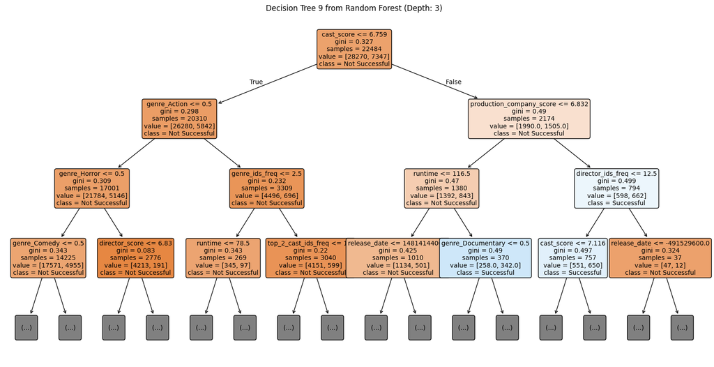

```python
plot_random_forest_tree(rf_with_scores, feature_names=X_train_with_scores.columns, tree_index=9, max_depth=3)
```

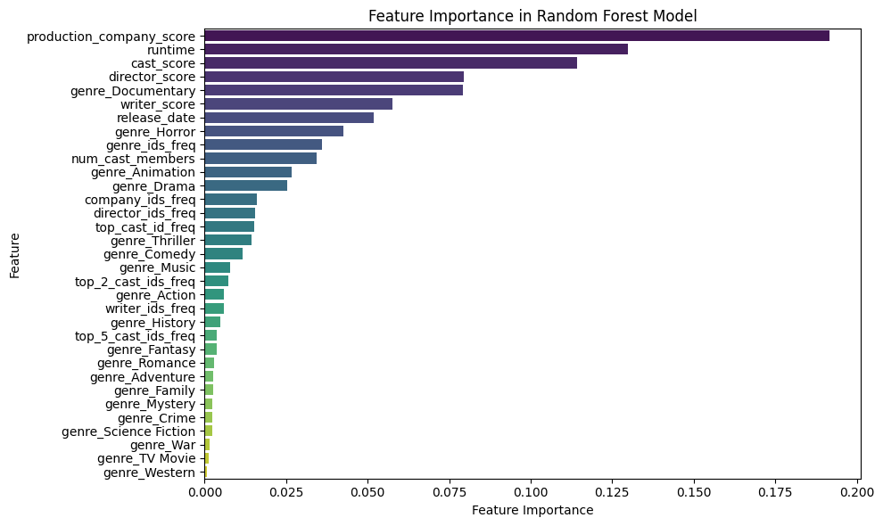

```python
plot_feature_importance(rf_with_scores, X_train_with_scores.columns)
```

### Predicting success on new releases with the new model

```python
df_with_scores_all = load_sql.fetch_predict_success_data(lambda_director, lambda_writers, lambda_cast_time, lambda_cast_order, min_votes=0)
new_movies_with_scores = df_with_scores_all[df_with_scores_all['release_date'].str.startswith(current_year)]
new_movies_with_scores.head()
```

|  | movie_id | vote_average | title | release_date | runtime | vote_count | top_cast_id | top_2_cast_ids | top_5_cast_ids | num_cast_members | ... | genre_Mystery | genre_Music | genre_Romance | genre_Family | genre_War | genre_TV Movie | director_score | writer_score | cast_score | production_company_score |
| --- | --- | --- | --- | --- | --- | --- | --- | --- | --- | --- | --- | --- | --- | --- | --- | --- | --- | --- | --- | --- | --- |
| 56548 | 83533 | 0.0 | Avatar: Fire and Ash | 2025-12-17 | 0 | 0.0 | 65731 | 65731,8691 | 65731,8691,10205,32747,204 | 24 | ... | 0 | 0 | 0 | 0 | 0 | 0 | 7.568475 | 7.170431 | 6.639269 | 6.860590 |
| 140012 | 257094 | 0.0 | Holland | 2025-03-09 | 108 | 0.0 | 2227 | 2227,258 | 2227,258,15576,1976054,3232669 | 10 | ... | 1 | 0 | 0 | 0 | 0 | 0 | 6.986000 | 6.292833 | 6.490638 | 6.372907 |
| 155948 | 277171 | 0.0 | Thingdom: El reino de las cosas | 2025-12-31 | 86 | 0.0 | 150885 | 150885,1331278 | 150885,1331278 | 2 | ... | 0 | 0 | 0 | 0 | 0 | 0 | 6.292833 | 6.292833 | 6.541491 | 6.292833 |
| 156808 | 278201 | 0.0 | Anpodu Kanmani | 2025-01-24 | 0 | 0.0 | 1440952 | 1440952,3276420 | 1440952,3276420,2037448,1855736,1696318 | 10 | ... | 0 | 0 | 0 | 1 | 0 | 0 | 6.292833 | 7.032142 | 7.110864 | 6.292833 |
| 158997 | 280951 | 3.0 | Madha Gaja Raja | 2025-01-12 | 142 | 1.0 | 559892 | 559892,141076 | 559892,141076,1118770,123068,95750 | 19 | ... | 0 | 0 | 1 | 0 | 0 | 0 | 6.292833 | 6.143827 | 6.450212 | 7.072500 |

5 rows × 37 columns

```python
new_movies_with_scores = pre_split_processing(new_movies_with_scores)
_, new_movies_with_scores_encoded = add_frequency_encoding(train_df_with_scores, new_movies_with_scores, categorical_cols)
X_new_movies_with_scores, _ = prepare_features(new_movies_with_scores_encoded)

predictions_with_scores = rf_with_scores.predict(X_new_movies_with_scores)
print(f"Number of movies predicted successful: {(predictions_with_scores == 1).sum()}")
print(f"Number of movies predicted unsuccessful: {(predictions_with_scores == 0).sum()}")
print(f"Proportion of movies predicted successful: {(predictions_with_scores == 1).sum()/len(X_new_movies_with_scores): .4f}")
```

```
Number of movies predicted successful: 278
Number of movies predicted unsuccessful: 12250
Proportion of movies predicted successful:  0.0222
```

```python
get_most_likely_successful(rf_with_scores, new_movies_with_scores, X_new_movies_with_scores).head(10)
```

|  | title | Success Probability | Predicted Label |
| --- | --- | --- | --- |
| 620585 | Ne Zha 2 | 0.810059 | Successful |
| 870458 | Red Velvet Happiness Diary : My Dear, ReVe1uv ... | 0.752646 | Successful |
| 873994 | Hans Zimmer & Friends: Diamond in the Desert | 0.720914 | Successful |
| 860993 | YOASOBI 5th ANNIVERSARY DOME LIVE 2024 "SURREA... | 0.706509 | Successful |
| 803193 | Rekhachithram | 0.702394 | Successful |
| 884357 | SEVENTEEN [RIGHT HERE] WORLD TOUR IN CINEMAS | 0.692339 | Successful |
| 549946 | Becoming Led Zeppelin | 0.691091 | Successful |
| 858174 | Mobile Suit Gundam GQuuuuuuX -Beginning- | 0.690338 | Successful |
| 794132 | Eric Clapton - Unplugged | 0.688975 | Successful |
| 879924 | Borrowed Time: Lennon's Last Decade | 0.683535 | Successful |

## Partial Dependence Plots & Business Takeaways

In this section, we create **Partial Dependence Plots (PDPs)** to explore how the model's predicted probability of movie success changes as we vary individual features. We focus on the four features with the highest feature importance identified earlier in the notebook: `production_company_score`, `runtime`, `cast_score`, and `director_score`. These plots offer insight into the **relationships the model has learned**, helping us generate **business-relevant interpretations** for features such as production company reputation, cast, director, and runtime.

> **Note on Model Limitations**: The model used here exhibits **high precision (~70%)** but **low recall (~15%)**. This means it tends to be correct when it predicts a movie will be successful, but it misses many movies that do succeed. As a result, the patterns seen in the PDPs should be treated as **indicative rather than definitive**, and interpreted as reflecting trends the model found useful — not universal truths.

```python
def make_pdp(model, X, features):
    """
    Generates Partial Dependence Plots (1D or 2D) for one or two features.

    Parameters:
    - model: Trained scikit-learn estimator (e.g., RandomForestClassifier)
    - X: DataFrame or array-like, the data used for computing the PDP
    - features: List of one or two feature names. For example:
        - ['runtime'] for 1D PDP
        - ['runtime', 'cast_score'] for 2D PDP

    Displays:
    - A line plot (1D) or contour plot (2D) showing the relationship between
      the specified features and the model's predicted outcome.
    """
    fig = plt.figure(figsize=(6, 5 if len(features) == 2 else 4))
    PartialDependenceDisplay.from_estimator(
        model,
        X,
        features=[features],
        kind='average',
        grid_resolution=50,
        ax=plt.gca()
    )
    title = "Partial Dependence of Success on " + " and ".join(features)
    plt.title(title)
    plt.tight_layout()
    plt.show()
```

### Production Company Score

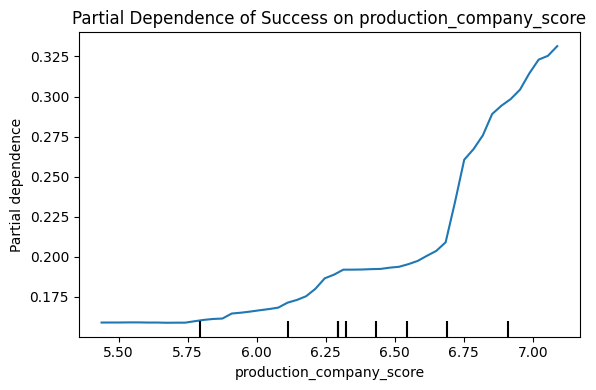

```python
make_pdp(rf_with_scores, X_train_with_scores, ['production_company_score'])
```

The partial dependence plot for `production_company_score` above provides a clear narrative about the **relationship the model has learned** between a movie’s likelihood of success and the historical performance of the production company behind it.

According to the model:

#### Business Takeaways (Based on Model Insights)

1. **Reputation boosts success**: Movies backed by production companies with higher scores are more likely to be predicted successful. These scores reflect a company's history of working on well-received projects, which may influence audience trust, critical reception, and distribution access.
2. **Breaking past a threshold matters**: The model shows a sharp rise in predicted success around a score of **6.7**, indicating a potential threshold where a company’s track record begins to significantly impact perceptions of movie success.

### Runtime

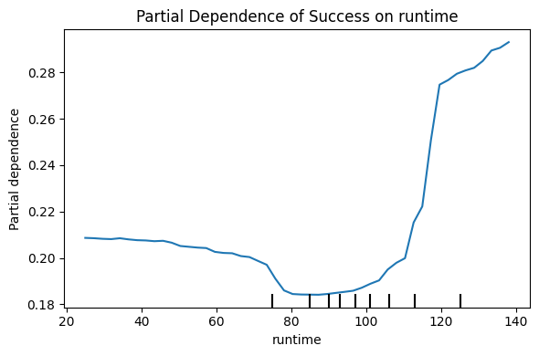

```python
make_pdp(rf_with_scores, X_train_with_scores, ['runtime'])
```

The partial dependence plot for `runtime` illustrates how the model relates a movie's duration to its likelihood of success.

According to the model:

- When `runtime` is just over **20 minutes**, the predicted success probability starts around **21%**. This likely reflects the presence of short-form content or niche entries, which the model associates with moderate success.
- As runtime increases toward **75 minutes**, the predicted probability **gradually declines** to about **20%**, followed by a **steeper drop** to approximately **18.5%** at **80 minutes**. This suggests that movies in the 75–80 minute range may be perceived — by the model — as lower quality or outside the typical feature-length standard.
- From **80 to 105 minutes**, the curve **rebounds modestly**, reaching about **19%**, and then rises more steadily to **20%** at **110 minutes**. This section reflects a transition zone where movies start aligning with standard feature film expectations.
- Between **110 and 120 minutes**, there's a **sharp increase** in predicted success probability, jumping from **20% to 28%**, signaling that films around the two-hour mark are viewed by the model as particularly promising.
- Beyond **120 minutes**, the upward trend **continues steadily**, reaching **30%** at a runtime of **140 minutes**, suggesting that — in the model's learned patterns — longer films may correlate with higher budgets, more developed narratives, or greater critical ambition.

#### Business Takeaways (Based on Model Insights)

1. **Avoid runtimes near the 80-minute mark**: The model predicts a dip in success probability for movies with runtimes around **75–80 minutes**, possibly due to falling short of feature-length expectations or being associated with lower-quality releases.
2. **Longer runtimes correlate with higher predicted success**: Starting around **110 minutes**, the model predicts a sharp and sustained increase in success likelihood, peaking at **140 minutes**. This trend may reflect the association between longer films and prestige or production value.
3. **Standard feature lengths perform best**: Runtimes between **100 and 140 minutes** fall within the model’s "sweet spot," balancing content depth and audience expectations. Targeting this range may improve predicted success.

### Cast and Director Scores

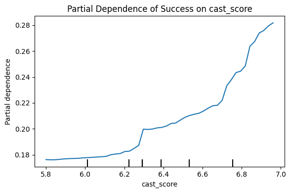

```python
make_pdp(rf_with_scores, X_train_with_scores, ['cast_score'])
```

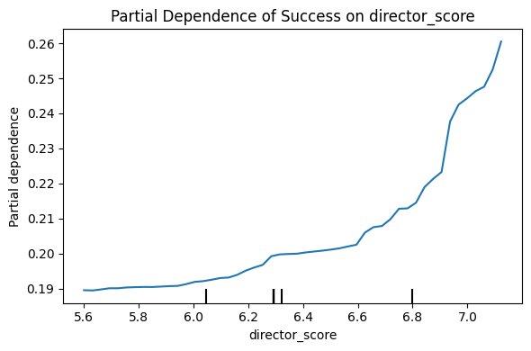

```python
make_pdp(rf_with_scores, X_train_with_scores, ['director_score'])
```

The partial dependence plots for `cast_score` and `director_score` provide insight into the **relationships the model has learned** between a movie’s likelihood of success and the historical success of its cast and director, respectively. Given their similar shapes, we interpret them together below.

According to the model:

- For both features, we observe an **initial slow increase** in predicted success.
  - For `cast_score`, the predicted probability rises slightly from **18% to 19%** as the score increases from **5.8 to 6.25**.
  - For `director_score`, the increase is similarly modest, from **19% to 20%** as the score goes from **5.6 to 6.25**.  
    This early phase suggests that modest improvements in cast or director quality (as measured by past project success) lead to only small increases in predicted success, possibly because the model perceives low-to-mid tier scores as relatively interchangeable.
- Around **6.25**, both plots exhibit an **acceleration in growth**, though with different dynamics:
  - For `cast_score`, the predicted success jumps quickly from **19% to 20%**, then continues rising steadily to **22% at a score of 6.7**, followed by a **faster linear increase** up to **28% when the score reaches 7.0**.
  - For `director_score`, the predicted probability increases more gradually from **20% to 20.5%** between **6.25 and 6.6**, then accelerates to **22.5% at 6.9**, and rises even more quickly to **26% at 7.1**.

These trends imply that the model sees higher-scoring cast and directors — those with a history of working on more successful films — as **increasingly strong signals for success**. The upward curves suggest that once a cast or director's score passes a certain point (around **6.6 to 6.7**), their presence becomes more valuable in the model’s predictions.

#### Business Takeaways (Based on Model Insights)

1. **Experienced talent improves predicted outcomes**: According to the model, hiring cast members and directors with strong prior success histories is associated with increased chances of predicted movie success. This aligns with industry expectations — experienced talent tends to draw more attention and potentially boost performance.
2. **Strong scores matter more after a threshold**: While early gains from improving talent scores are modest, the model suggests **notable gains once cast or director scores exceed ~6.6**. This may reflect an inflection point where the perceived credibility and marketability of high-scoring talent becomes significantly impactful.
3. **Investing in top-tier talent pays off**: The steeper rise in predicted success beyond a score of 6.7–7.0 suggests that the model captures a familiar industry intuition: hiring high-scoring directors and cast members — even if expensive — is associated with significantly higher odds of success.